Skip to main content

# Practical 2 — Superstore order size

Numerical summaries, distributions and unusual orders · 307312 Applied Statistics

- Companion to centre, spread, percentiles and boxplots in Part 2.
- Continue from Practical 1.
- Allow two sessions of about 40–50 minutes.

**By the end, you should be able to:**

- Aggregate transactions at the correct level.
- Explain the difference between typical order size and total revenue.
- Describe skewness, spread and percentile thresholds.
- Investigate unusual records while preserving the complete analysis.

## 1. The operations manager’s question

> What is a typical order worth, and how much variation must operations accommodate?
- **Unit:** one order after combining all its product lines.
- **Source:** Tableau’s fictitious Superstore, downloaded 6 November 2026.
- **Scope:** United States; orders placed in 2023–2025.
- **Records:** 3,322 orders built from 6,682 product lines.
- **Amounts:** recorded dollars; `sales` is the line/order sales field, not a list price.
- **Limit:** these describe the course extract, not actual future sales.

## 2. Import and aggregate

```r
source("lessons/_includes/course-tools.R")
lines <- read.csv("data/business/superstore-lines.csv",
                  stringsAsFactors = FALSE, colClasses = c(postal_code = "character"))
orders <- make_orders(lines)
stopifnot(nrow(orders) == n_distinct(lines$order_id),
          isTRUE(all.equal(sum(orders$sales), sum(lines$sales))))
knitr::kable(head(orders[c("order_id", "sales", "profit", "quantity", "line_count")] ), digits = 2)
```

| order_id | sales | profit | quantity | line_count |
| --- | --- | --- | --- | --- |
| US-2023-100006 | 377.97 | 109.61 | 3 | 1 |
| US-2023-100090 | 699.19 | -19.09 | 9 | 2 |
| US-2023-100279 | 22.38 | 10.74 | 2 | 1 |
| US-2023-100293 | 91.06 | 31.87 | 6 | 1 |
| US-2023-100328 | 3.93 | 1.33 | 1 | 1 |
| US-2023-100363 | 21.38 | 7.72 | 5 | 2 |

- `data/business/superstore-lines.csv`; guide: `data/business/README.md`.
- Sales, profit and quantity are **summed** across an order’s lines.
- Do not average line sales to estimate average order sales.
- The reconciliation checks that aggregation neither loses nor duplicates revenue.

## 3. Look at the distribution first

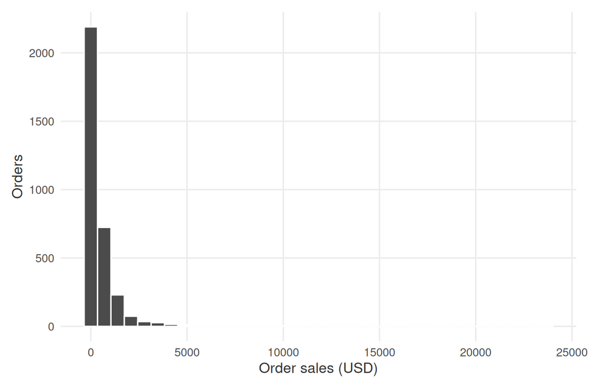

```r
ggplot(orders, aes(sales)) +
  geom_histogram(bins = 35, fill = petra_ink, colour = "white") +
  labs(x = "Order sales (USD)", y = "Orders")
```

- Most orders are relatively small; a few are very large.
- The long right tail affects the mean and SD.
- A histogram’s bin width changes the visible detail.
- A tall bar shows many orders in an interval, not many dollars of revenue.

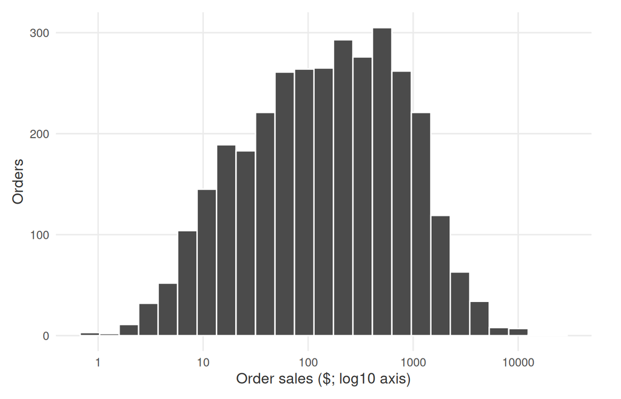

```r
ggplot(orders, aes(sales)) +
  geom_histogram(bins = 25, fill = petra_ink, colour = "white") +
  scale_x_log10() + labs(x = "Order sales ($; log10 axis)", y = "Orders")
```

- The log axis makes the lower range easier to inspect without deleting large orders.
- Equal spacing on this axis means equal ratios, not equal dollar differences.

## 4. Choose useful numerical measures

```r
x <- orders$sales
summary_table <- data.frame(
  statistic = c("Orders", "Mean (USD)", "Median (USD)", "Sample SD (USD)",
                "Minimum (USD)", "Q1 (USD)", "Q3 (USD)", "Maximum (USD)", "IQR (USD)"),
  value = c(length(x), mean(x), median(x), sd(x), min(x),
            quantile(x, .25, type = 7), quantile(x, .75, type = 7), max(x), IQR(x)))
knitr::kable(summary_table, digits = 2)
```

| statistic | value |
| --- | --- |
| Orders | 3322.00 |
| Mean (USD) | 470.80 |
| Median (USD) | 153.98 |
| Sample SD (USD) | 982.97 |
| Minimum (USD) | 0.84 |
| Q1 (USD) | 38.71 |
| Q3 (USD) | 535.34 |
| Maximum (USD) | 23661.23 |
| IQR (USD) | 496.62 |

- Mean order sales: about **$471**.
- Median order sales: about **$154**.
- Mean explains revenue per order; median describes the middle order.
- SD is sensitive to the right tail; IQR describes the middle half.
- `sd()` uses denominator $n-1$; the frame SD uses $N$ and is slightly smaller here.

### Revenue reconciliation

```r
c(total_sales = sum(x), mean_times_orders = mean(x) * length(x),
  median_times_orders = median(x) * length(x))
```

```
        total_sales   mean_times_orders median_times_orders
          1563985.6           1563985.6            511528.2
```

- Mean × number of orders reproduces total revenue.
- Median × number of orders generally does not.
- The median is not an alternative way to calculate the total.

### Absolute and relative spread

```r
c(range_dollars = diff(range(x)),
  mean_absolute_deviation = mean(abs(x - mean(x))),
  coefficient_of_variation_pct = 100 * sd(x) / mean(x))
```

```
               range_dollars      mean_absolute_deviation
                  23660.3920                     501.6800
coefficient_of_variation_pct
                    208.7897
```

- Mean absolute deviation above is not R’s `mad()`, which uses the median and a scaling constant.
- CV is appropriate here because sales have a meaningful zero and positive mean.
- Do not apply the same CV rule to profits that can be negative or near zero on average.

## 5. Percentiles for operational planning

> What order values define the upper 10% and upper 5% of the observed distribution?

```r
knitr::kable(data.frame(percentile = c("50th", "75th", "90th", "95th", "99th"),
  order_sales = as.numeric(quantile(x, c(.5, .75, .9, .95, .99), type = 7))), digits = 2)
```

| percentile | order_sales |
| --- | --- |
| 50th | 153.98 |
| 75th | 535.34 |
| 90th | 1190.81 |
| 95th | 1799.67 |
| 99th | 4277.10 |

- Percentiles describe positions in the observed distribution.
- Interpolation and ties mean a threshold may not leave exactly the named percentage strictly above it.
- A sales percentile does not directly measure parcel size, picking time or staffing needs.
- Additional operational variables would be needed for those decisions.

## 6. Boxplots and unusual orders

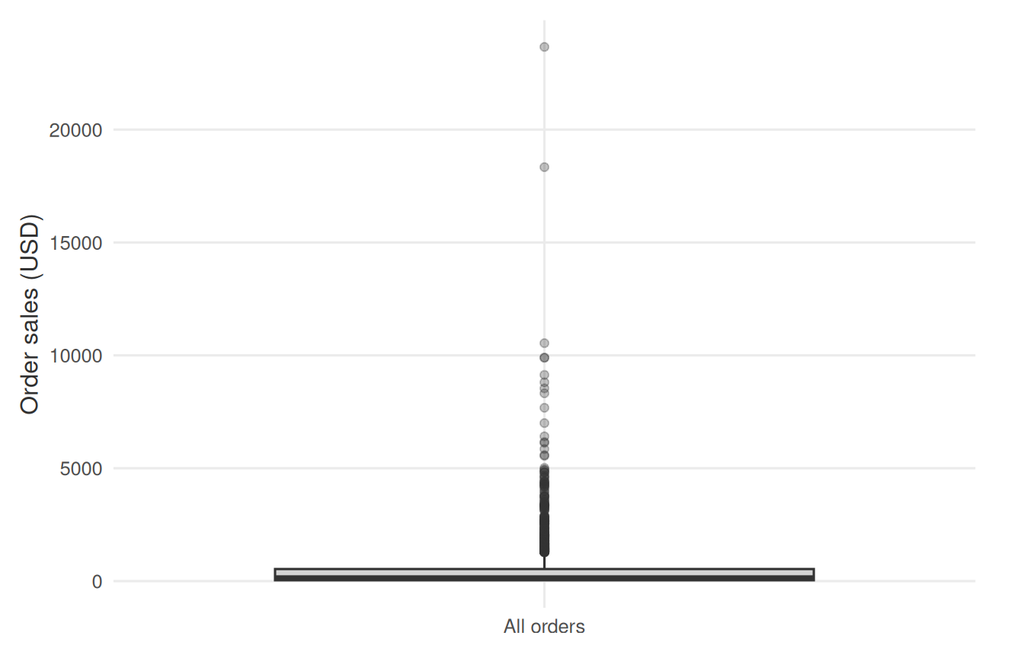

```r
ggplot(orders, aes(x = "All orders", y = sales)) +
  geom_boxplot(fill = petra_accent, outlier.alpha = .3) +
  labs(x = NULL, y = "Order sales (USD)")
```

```r
quartiles <- quantile(x, c(.25, .75), type = 7)
lower_fence <- quartiles[1] - 1.5 * IQR(x)
upper_fence <- quartiles[2] + 1.5 * IQR(x)
flagged <- orders %>% filter(sales < lower_fence | sales > upper_fence)
c(lower_fence = lower_fence, upper_fence = upper_fence, flagged_orders = nrow(flagged))
```

```
lower_fence.25% upper_fence.75%  flagged_orders
      -706.2188       1280.2713        301.0000
```

- Flags identify records worth investigating.
- The source contains genuine large recorded transactions; a flag alone does not establish an error.
- Boxplot hinges and reported quartiles can differ slightly for some sample sizes.

```r
knitr::kable(orders %>% arrange(desc(sales)) %>%
  select(order_id, sales, profit, line_count, quantity) %>% head(5), digits = 2)
```

| order_id | sales | profit | line_count | quantity |
| --- | --- | --- | --- | --- |
| US-2023-145317 | 23661.23 | -1789.73 | 7 | 25 |
| US-2025-118689 | 18336.74 | 8762.39 | 5 | 18 |
| US-2023-139892 | 10539.90 | -1878.79 | 7 | 37 |
| US-2023-116904 | 9900.19 | 4668.69 | 4 | 17 |
| US-2025-117121 | 9892.74 | 4946.37 | 1 | 13 |

- Inspect the underlying product lines before deciding what a large order means.
- A large order may contain one costly product or several products.
- Keep all records in the main summary.

### A labelled sensitivity comparison

```r
central_orders <- orders %>% filter(sales >= lower_fence, sales <= upper_fence)
knitr::kable(data.frame(
  scope = c("Full frame — primary result", "Within IQR fences — sensitivity only"),
  n = c(nrow(orders), nrow(central_orders)),
  mean_sales = c(mean(orders$sales), mean(central_orders$sales)),
  median_sales = c(median(orders$sales), median(central_orders$sales))), digits = 2)
```

| scope | n | mean_sales | median_sales |
| --- | --- | --- | --- |
| Full frame — primary result | 3322 | 470.80 | 153.98 |
| Within IQR fences — sensitivity only | 3021 | 257.91 | 121.44 |

- The second row changes the scope; it is not a corrected estimate of the original frame mean.
- Large changes show why valid extreme values matter to the business.
- Do not hide exclusions or present the smaller mean as the retailer’s full average order value.

## 7. Independent operations briefing

1. Compare order sales across regions using $n$, mean, median, SD and IQR.
2. Draw side-by-side boxplots, with the same scale for all regions.
3. Find the region with the largest **total revenue** and the largest **median order**. Are they the same?
4. Identify the top five orders by sales and inspect their product lines.
5. Calculate the share of total revenue contributed by the top 10% of orders ranked by sales. State how you handle ties or rounding of the number of orders.
6. Write a short briefing distinguishing typical size, variability and revenue concentration.

```r
# group_by(region) %>% summarise(...) builds the regional table.
# arrange(desc(sales)) ranks order records.
# An explicit rule is to take ceiling(0.10 * nrow(orders)) highest-ranked orders.
```

**Your conclusion should include:**

- The scope and order-level denominator.
- Two numerical findings with dollar units.
- One useful operational follow-up.
- A limitation: sales values alone do not measure physical workload.

## 8. Continue

- Practical 3: Discounts and profitability.
- `data/business/README.md`.